# 9. Determinar años requeridos con método objetivo

# Introducción

En este documento se intentará determinar los años de educación requeridos en cada grupo ocupacional mediante el método objetivo que establece la Organización Internacional de Trabajo (ILO, por sus siglas en inglés) y que, a su vez, utiliza para los [Indicadores de Educación y Desajuste](https://ilostat.ilo.org/methods/concepts-and-definitions/description-education-and-mismatch-indicators) (EMI, por sus siglas en inglés). Para ver un ejemplo de la utilización del método, véase ILO (2021) la cual señala un desajuste de 50% a nivel mundial.

# Librerías

```r
# paquetes ==========================================================
library(tidyverse)
```

```r
# paleta de colores p. 422
library(RColorBrewer)
# letter value plot p. 99 (inglés)
library(lvplot)
# # calcular la moda
# library(DescTools)
# # coeficiente de asimetría
# library(moments)
# library(EnvStats)
library(modelr)
# análisis de residuos
library(performance)
library(car)
library(stats)
library(nortest)
library(moments)
library(lmtest)
library(see)
```

# Importación

```r
# importación =======================================================
# 3. sociodemográfica
sdem <- read_csv(
  "enoet22025/ENOE_SDEMT225.csv",
  col_types = cols(.default = col_character())
)

# 4. ocupación y empleo I
coe1 <- read_csv(
  "enoet22025/ENOE_COE1T225.csv",
  col_types = cols(.default = col_character())
)

# 5. ocupación y empleo II
coe2 <- read_csv(
  "enoet22025/ENOE_COE2T225.csv",
  col_types = cols(.default = col_character())
)
```

# Segmentación

```r
# segmentación ======================================================
sdem<- sdem %>% mutate(
  # edad
  eda = as.integer(eda),
  # años de escolaridad
  escolaridad = as.integer(anios_esc),
  # 99 pasa a NA para evitar 99 - edu_req
  escolaridad = if_else(escolaridad != 99, escolaridad, NA),
  # grado escolar
  grado_esc = as.integer(cs_p13_1),
  # 99 pasa a NA para evitar 99 - edu_req
  grado_esc = if_else(grado_esc != 99, grado_esc, NA),
  # ponderador trimestral
  fac_tri = as.double(fac_tri),
  # ingreso mensual
  ing_mensual = as.double(ingocup),
  # 0 pasa a NA ya que 0==NA en p6b2
  ing_mensual = if_else(ing_mensual != 0, ing_mensual, NA),
  # promedio de ingreso por hora
  ing_hora = as.double(ing_x_hrs),
  # 0 pasa a NA ya que 0==NA en p6b2 y en dur9c == 1 & 9
  ing_hora = if_else(ing_hora != 0, ing_hora, NA)
)
```

Carrera técnica

```r
sdem %>%
  filter(grado_esc >= 5) %>%
  count(grado_esc, escolaridad)
```

| grado_esc | escolaridad | n |
| --- | --- | --- |
| 5 | 0 | 1 |
| 5 | 10 | 6 |
| 5 | 11 | 19 |
| 5 | 12 | 364 |
| 5 | 13 | 721 |
| 5 | NA | 14 |
| 6 | 0 | 19 |
| 6 | 7 | 47 |
| 6 | 8 | 216 |
| 6 | 9 | 536 |

[output cut: 30 more lines]

Hay valores desde `0` en `escolaridad`, ¿qué pasa si considero a sólo los que terminaron sus estudios?

```r
sdem %>%
  filter(grado_esc >= 5) %>%
  select(contains("cs_p13"), cs_p16, anios_esc, escolaridad) %>%
  arrange(anios_esc)
```

| cs_p13_1 | cs_p13_2 | cs_p16 | anios_esc | escolaridad |
| --- | --- | --- | --- | --- |
| 7 | 3 | 1 | 0 | 0 |
| 7 | 5 | 1 | 0 | 0 |
| 7 | 4 | 1 | 0 | 0 |
| 7 | 1 | 2 | 0 | 0 |
| 7 | 3 | 2 | 0 | 0 |
| 7 | 4 | 1 | 0 | 0 |
| 7 | 4 | 2 | 0 | 0 |
| 7 | 4 | 1 | 0 | 0 |
| 7 | 5 | 1 | 0 | 0 |
| 7 | 5 | 1 | 0 | 0 |

[output cut: 9990 more lines]

¿Qué representa el valor `0` en `anios_esc`?

```r
sdem %>%
  select(contains("cs_p13"), cs_p16, anios_esc, escolaridad) %>%
  filter(anios_esc == 0) %>%
  count(cs_p13_1)
```

| cs_p13_1 | n |
| --- | --- |
| 0 | 13278 |
| 1 | 14088 |
| 2 | 30047 |
| 3 | 191 |
| 4 | 172 |
| 5 | 1 |
| 6 | 19 |
| 7 | 238 |
| 8 | 28 |
| 9 | 2 |

[output cut: 2 more lines]

```r
# sdem %>%
#   select(contains("cs_p13"), cs_p16, anios_esc, escolaridad) %>%
#   filter(anios_esc == 0)
```

¿Es un error de código al multiplicar `cs_p13_1` con `cs_p13_2`? Se registra duda como actividad a realizar en Notion.

**AQUÍ ME QUEDÉ**

# Construcción de variables

```r
# construcción de variables =========================================
# grupos de edad OECD(2019: 135)
sdem <- sdem %>%
  mutate(
    edad_7g = case_when(
      between(eda, 0, 14) ~ "1",
      between(eda, 15, 24) ~ "2",
      between(eda, 25, 34) ~ "3",
      between(eda, 35, 44) ~ "4",
      between(eda, 45, 54) ~ "5",
      between(eda, 55, 64) ~ "6",
      between(eda, 65, 97) ~ "7",
      # edad no especificada mayores a 12 INEGI(2024:16)
      eda == "98" ~ "98",
      # edad no especificada menores a 12 INEGI(2024:16)
      eda == "99" ~ "99",
      # NA sin comillas para valores faltantes
      TRUE ~ NA
    )
  )

# carreras universitaria INEGI(2016: 13)
sdem <- sdem %>%
  mutate(
    carrera1 = if_else(str_length(cs_p14_c) == 5, str_c("0", cs_p14_c), cs_p14_c),
    carrera2 = if_else(str_length(cs_p14_c) == 5, str_c("0", cs_p14_c), cs_p14_c),
    carrera3 = if_else(str_length(cs_p14_c) == 5, str_c("0", cs_p14_c), cs_p14_c)
  ) %>%
  separate(
    carrera1,
    # campo amplio
    into = c("carrera1", "res"),
    sep = 2
  ) %>%
  separate(
    carrera2,
    # campo específico
    into = c("carrera2", "res"),
    sep = 3
  ) %>%
  separate(
    carrera3,
    # campo detallado
    into = c("carrera3", "res"),
    sep = 4
  ) %>%
  select(-res)

# grupos ocupacionales INEGI(2019: 22)
coe1 <- coe1 %>%
  mutate(
    ocupacion1 = p3,
    ocupacion2 = p3,
    ocupacion3 = p3
  ) %>%
  separate(
    ocupacion1,
    into = c("ocupacion1", "res"),
    sep = 1
  ) %>%
  separate(
    ocupacion2,
    into = c("ocupacion2", "res"),
    sep = 2
  ) %>%
  separate(
    ocupacion3,
    into = c("ocupacion3", "res"),
    sep = 3
  ) %>%
  select(-res)
```

Comprobación

```r
# carreras universitarias
sdem %>%
  filter(!is.na(cs_p14_c)) %>%
  select(cs_p14_c, contains("carrera"))
```

| cs_p14_c | carrera1 | carrera2 | carrera3 |
| --- | --- | --- | --- |
| 42100 | 04 | 042 | 0421 |
| 92100 | 09 | 092 | 0921 |
| 42100 | 04 | 042 | 0421 |
| 41200 | 04 | 041 | 0412 |
| 33100 | 03 | 033 | 0331 |
| 101400 | 10 | 101 | 1014 |
| 41400 | 04 | 041 | 0414 |
| 91345 | 09 | 091 | 0913 |
| 33100 | 03 | 033 | 0331 |
| 12702 | 01 | 012 | 0127 |

[output cut: 9990 more lines]

```r
# grupos ocupacionales
coe1 %>%
  filter(!is.na(p3)) %>%
  select(p3, contains("ocupacion"))
```

| p3 | ocupacion1 | ocupacion2 | ocupacion3 |
| --- | --- | --- | --- |
| 4211 | 4 | 42 | 421 |
| 7222 | 7 | 72 | 722 |
| 4224 | 4 | 42 | 422 |
| 9721 | 9 | 97 | 972 |
| 4211 | 4 | 42 | 421 |
| 5116 | 5 | 51 | 511 |
| 8342 | 8 | 83 | 834 |
| 3212 | 3 | 32 | 321 |
| 4111 | 4 | 41 | 411 |
| 3115 | 3 | 31 | 311 |

[output cut: 9990 more lines]

# Creación de tablas

```r
# creación de tablas ================================================
# población total INEGI(2023:21)
pob_total <- sdem %>%
  filter(
    r_def == "0",
    # es igual a (c_res == "1" | c_res == "3")
    c_res != "2"
  )

# población de 12 y más para unir sdem y coe INEGI(2023:9)
pob_12ymas <- sdem %>%
  filter(
  r_def == "0",
  c_res != "2",
  between(eda, 12, 98)
  )

# unión de sdem y coe INEGI(2023:9)
completo <- pob_12ymas %>%
  full_join(coe1, by = c("tipo", "mes_cal", "ent", "con", "v_sel", "n_hog", "h_mud", "n_ren")) %>%
  full_join(coe2, by = c("tipo", "mes_cal", "ent", "con", "v_sel", "n_hog", "h_mud", "n_ren"))

# población de 15 años y más INEGI(2023:21)
pob_15ymas <- completo %>%
  filter(
    r_def.x == "0",
    c_res != "2",
    between(eda.x, 15, 98)
  )

# INEGI(2023: 21)
ocupada <- pob_15ymas %>%
  filter(clase2 == 1)

# INEGI(2023: 25)
desocupada <- pob_15ymas %>%
  filter(clase2 == 2)

# INEGI(2023: 26)
pnea <- pob_15ymas %>%
  filter(clase1 == 2)
```

# Sobre-educación

## Construcción de educación requerida en las ocupaciones

De acuerdo a la Organización Internacional del Trabajo (*ILO*, por sus siglas en inglés), se determina el grado escolar requerido a 1 dígito de las ocupaciones, es decir, mediante el grupo **división** INEGI (2020) p. 29. La ILO utiliza el método objetivo, también conocido como método normativo, para determinar el grado escolar, y no los años de escolaridad, requeridos en cada grupo ocupacional para los [Indicadores de Educación y Desajuste](https://ilostat.ilo.org/methods/concepts-and-definitions/description-education-and-mismatch-indicators) (*EMI*, por sus siglas en inglés). La siguiente tabla describe el nivel de competencia (*skill level*) requerido, o adecuado, para cada grupo ocupacional, según la Clasificación Internacional Uniforme de Ocupaciones (CIUO, o ISCO por sus siglas en inglés) y, a su vez, se especifica el nivel escolar (*level of education*) equivalente de acuerdo al nivel de competencia, según la Clasificación Internacional Normalizada de la Educación (CINE, o ISCED por sus siglas en inglés).

| ISCO-08 skill level | ISCED-11 | ISCO-08 |
| --- | --- | --- |
| Skill level 3 and 4 | 3: 5. Short-cycle tertiary education 4: 6. Bachelor’s or equivalent level 7. Master’s or equivalent level 8. Doctoral or equivalent level | 1 Managers (Personal directivo de la administración pública y de empresas y miembros del poder ejecutivo y de los cuerpos legislativos) |
| Skill level 4 | 6. Bachelor’s or equivalent level 7. Master’s or equivalent level 8. Doctoral or equivalent level | 2 Professionals (Profesionales científicos e intelectuales) |
| Skill level 3 | 5. Short-cycle tertiary education | 3 Technicians and Associate Professionals (Técnicos profesionales de nivel medio) |
| Skill level 2 | 2. Lower secondary education 3. Upper secondary education 4. Post-secondary non-tertiary education | 4 Clerical Support Workers (Empleados administrativos de oficina) |
| Skill level 2 | 2. Lower secondary education 3. Upper secondary education 4. Post-secondary non-tertiary education | 5 Services and Sales Workers (Trabajadores de los servicios y vendedores de comercios y mercados) |
| Skill level 2 | 2. Lower secondary education 3. Upper secondary education 4. Post-secondary non-tertiary education | 6 Skilled Agricultural, Forestry and Fishery Workers (Agricultores y trabajadores califi cados agropecuarios, forestales y pesqueros) |
| Skill level 2 | 2. Lower secondary education 3. Upper secondary education 4. Post-secondary non-tertiary education | 7 Craft and Related Trades Workers (Oficiales, operarios y artesanos de artes mecánicas y de otros oficios) |
| Skill level 2 | 2. Lower secondary education 3. Upper secondary education 4. Post-secondary non-tertiary education | 8 Plant and Machine Operators and Assemblers (Operadores de instalaciones y máquinas, y montadores) |
| Skill level 1 | 1. Primary education | 9 Elementary Occupations (Trabajadores no calificados) |

Fuente: ILO; ISCO; ISCED Nota: traducción de las ocupaciones basadas en INEGI(2011: 277-278)

Según INEGI (2016) (pp. 75-76), el grado escolar del Sistema Educativo Nacional equivalente a cada nivel escolar de CINE-11 que, a su vez, corresponde con cada valor de `cs_p13_1` INEGI (2024) p. 16; cabe señalar que para hacer el emparejamiento con cada valor de `cs_p13_1` nos basamos en el cuadro mostrado en INEGI (2016) p. 11.

| ISCO-08 skill level | ISCED-11 levels of education | Sistema Educativo Nacional de México | `cs_p13_1` |
| --- | --- | --- | --- |
|  | X. No schooling |  | 0 Ninguna |
|  | 0. Early childhood education | Preescolar | 1 Preescolar |
| Skill level 1 | 1. Primary education | Primaria | 2 Primaria |
| Skill level 2 | 2. Lower secondary education | Secundaria | 3 Secundaria |
| Skill level 2 | 3. Upper secondary education | Tipo medio superior Bachillerato general Profesional técnico, profesional técnico bachiller y bachillerato tecnológico | 4 Preparatoria |
| Skill level 2 | 4. Post-secondary non-tertiary education | No hay equivalente |  |
| Skill level 3 | 5. Short-cycle tertiary education | Tipo superior Técnico superior (incluye: profesional asociado, técnico superior universitario y licencia profesional) | 6 Carrera técnica |
| Skill level 4 | 6. Bachelor’s or equivalent level | Licenciatura (normal, universitaria y tecnológica) | 5 Normal 7 Profesional |
| Skill level 4 | 7. Master’s or equivalent level | Maestría | 8 Maestría |
| Skill level 4 | 8. Doctoral or equivalent level | Doctorado | 9 Doctorado |
| Skill level 4 | 9. Not elsewhere classified |  | 99 No sabe |

Fuente: ISCED; INEGI (2016: pp. 11; 75-76)

Ahora, se debe convertir los grupos ocupacionales de CUIO-08 a SINCO-19; para esto no existe un documento que nos oriente a realizar la conversión, solamente INEGI (2020) señala que la SINCO-19 tiene como principio de clasificación: “Se apega, en la medida de lo posible, a la CIUO de 2008 de la OIT y considera de las clasificaciones de ocupaciones de Canadá y Estados Unidos de América, los aspectos teóricos y metodológicos en los que coinciden con la internacional.” p. 17. Y en cuanto a SINCO-11 (INEGI, 2011: 277-278) sólo muestra la traducción al español de los grupos de CUIO-08, pero NO su ocupación equivalente a SINCO. Por lo que se propone la siguiente conversión con su respectivo grado escolar correspondiente:

| ISCO-08 skill level | ISCO-08 | SINCO-19 | Grado escolar | `cs_p13_1` |
| --- | --- | --- | --- | --- |
| Skill level 3 and 4 | 1 Managers (Personal directivo de la administración pública y de empresas y miembros del poder ejecutivo y de los cuerpos legislativos) | 1 Funcionarios, directores y jefes | Técnico superior Licenciatura (normal, universitaria y tecnológica) Maestría Doctorado | 6 Carrera técnica 5 Normal 7 Profesional 8 Maestría 9 Doctorado |
| Skill level 4 | 2 Professionals (Profesionales científicos e intelectuales) | 2 Profesionistas y técnicos | Licenciatura (normal, universitaria y tecnológica) Maestría Doctorado | 5 Normal 7 Profesional 8 Maestría 9 Doctorado |
| Skill level 3 | 3 Technicians and Associate Professionals (Técnicos profesionales de nivel medio) | 2 Profesionistas y técnicos | Técnico superior | 6 Carrera técnica |
| Skill level 2 | 4 Clerical Support Workers (Empleados administrativos de oficina) | 3 Trabajadores auxiliares en actividades administrativas | Secundaria Tipo medio superior | 3 Secundaria 4 Preparatoria |
| Skill level 2 | 5 Services and Sales Workers (Trabajadores de los servicios y vendedores de comercios y mercados) | 4 Comerciantes, empleados en ventas y agentes de ventas 5 Trabajadores en servicios personales y de vigilancia | Secundaria Tipo medio superior | 3 Secundaria 4 Preparatoria |
| Skill level 2 | 6 Skilled Agricultural, Forestry and Fishery Workers (Agricultores y trabajadores calificados agropecuarios, forestales y pesqueros) | 6 Trabajadores en actividades agrícolas, ganaderas, forestales, caza y pesca | Secundaria Tipo medio superior | 3 Secundaria 4 Preparatoria |
| Skill level 2 | 7 Craft and Related Trades Workers (Oficiales, operarios y artesanos de artes mecánicas y de otros oficios) | 7 Trabajadores artesanales, en la construcción y otros oficios | Secundaria Tipo medio superior | 3 Secundaria 4 Preparatoria |
| Skill level 2 | 8 Plant and Machine Operators and Assemblers (Operadores de instalaciones y máquinas, y montadores) | 8 Operadores de maquinaria industrial, ensambladores, choferes y conductores de transporte | Secundaria Tipo medio superior | 3 Secundaria 4 Preparatoria |
| Skill level 1 | 9 Elementary Occupations (Trabajadores no calificados) | 9 Trabajadores en actividades elementales y de apoyo | Primaria | 2 Primaria |

Fuente: elaboración propia con datos de ILO, ISCO-08, ISCED-11, INEGI(2011; 2016; 2020)

En resumen, el nivel de educación, grado escolar, requerida para cada grupo ocupacional a 1 dígito es el siguiente:

| SINCO-19 | `cs_p13_1` |
| --- | --- |
| 1 Funcionarios, directores y jefes | 5 Normal 6 Carrera técnica 7 Profesional 8 Maestría 9 Doctorado |
| 2 Profesionistas y técnicos | 5 Normal 6 Carrera técnica 7 Profesional 8 Maestría 9 Doctorado |
| 3 Trabajadores auxiliares en actividades administrativas | 3 Secundaria 4 Preparatoria |
| 4 Comerciantes, empleados en ventas y agentes de ventas 5 Trabajadores en servicios personales y de vigilancia | 3 Secundaria 4 Preparatoria |
| 6 Trabajadores en actividades agrícolas, ganaderas, forestales, caza y pesca | 3 Secundaria 4 Preparatoria |
| 7 Trabajadores artesanales, en la construcción y otros oficios | 3 Secundaria 4 Preparatoria |
| 8 Operadores de maquinaria industrial, ensambladores, choferes y conductores de transporte | 3 Secundaria 4 Preparatoria |
| 9 Trabajadores en actividades elementales y de apoyo | 2 Primaria |

Fuente: elaboración propia con datos de ILO, ISCO-08, ISCED-11, INEGI(2011; 2016; 2020)

Ahora, se procede a realizar el código para agregar la educación requerida.

```r
# sobre-educación ===================================================

# con el grupo división INEGI(2020: 22) -----------------------------
# método: objetivo
edu_req3_ocu1 <- ocupada %>%
  count(ocupacion1) %>%
  mutate(
    objetivo_min = case_when(
      ocupacion1 == 1 ~ 5,
      ocupacion1 == 2 ~ 5,
      ocupacion1 == 3 ~ 3,
      ocupacion1 == 4 ~ 3,
      ocupacion1 == 5 ~ 3,
      ocupacion1 == 6 ~ 3,
      ocupacion1 == 7 ~ 3,
      ocupacion1 == 8 ~ 3,
      ocupacion1 == 9 ~ 2,
      TRUE ~ NA
    ),
    objetivo_max = case_when(
      ocupacion1 == 1 ~ 9,
      ocupacion1 == 2 ~ 9,
      ocupacion1 == 3 ~ 4,
      ocupacion1 == 4 ~ 4,
      ocupacion1 == 5 ~ 4,
      ocupacion1 == 6 ~ 4,
      ocupacion1 == 7 ~ 4,
      ocupacion1 == 8 ~ 4,
      ocupacion1 == 9 ~ 2,
      TRUE ~ NA
    ),
    objetivo_min = as.integer(objetivo_min),
    objetivo_max = as.integer(objetivo_max)
  ) %>%
  select(-n)
```

Comprobación

```r
edu_req3_ocu1
```

| ocupacion1 | objetivo_min | objetivo_max |
| --- | --- | --- |
| 1 | 5 | 9 |
| 2 | 5 | 9 |
| 3 | 3 | 4 |
| 4 | 3 | 4 |
| 5 | 3 | 4 |
| 6 | 3 | 4 |
| 7 | 3 | 4 |
| 8 | 3 | 4 |
| 9 | 2 | 2 |

## Determinación de la incidencia

Comprobación

```r
ocupada %>% left_join(edu_req3_ocu1, by = "ocupacion1") %>%
  mutate(
    # objetivo
    edu_mis_obj_ocu1 = case_when(
      # required
      between(grado_esc, objetivo_min, objetivo_max) ~ 0,
      grado_esc > objetivo_max ~ 1,
      grado_esc < objetivo_min ~ 2,
      TRUE ~ NA
    )
  ) %>%
  select(ocupacion1, grado_esc, contains("objetivo_"), edu_mis_obj_ocu1)
```

| ocupacion1 | grado_esc | objetivo_min | objetivo_max | edu_mis_obj_ocu1 |
| --- | --- | --- | --- | --- |
| 4 | 7 | 3 | 4 | 1 |
| 3 | 2 | 3 | 4 | 2 |
| 3 | 3 | 3 | 4 | 0 |
| 8 | 3 | 3 | 4 | 0 |
| 8 | 3 | 3 | 4 | 0 |
| 9 | 3 | 2 | 2 | 1 |
| 9 | 3 | 2 | 2 | 1 |
| 2 | 4 | 5 | 9 | 2 |
| 4 | 3 | 3 | 4 | 0 |
| 2 | 7 | 5 | 9 | 0 |

[output cut: 9990 more lines]

```r
# variable de desajuste educativo
# desajuste_educativo <-
ocupada %>% left_join(edu_req3_ocu1, by = "ocupacion1") %>%
  mutate(
    # objetivo
    edu_mis_obj_ocu1 = case_when(
      # required
      between(grado_esc, objetivo_min, objetivo_max) ~ 0,
      grado_esc > objetivo_max ~ 1,
      grado_esc < objetivo_min ~ 2,
      TRUE ~ NA
    ),
    # variables binarias
    # objetivo
    over_obj_ocu1 = if_else(grado_esc > objetivo_max, 1, 0),
    req_obj_ocu1 = if_else(between(grado_esc, objetivo_min, objetivo_max), 1, 0),
    under_obj_ocu1 = if_else(grado_esc < objetivo_max, 1, 0)
    # variables de años de sobre o infra
    # con el objetivo no se puede obtener ya que son grados y están en intervalos
  ) %>%
  select(ocupacion1, grado_esc, objetivo_min:under_obj_ocu1)
```

| ocupacion1 | grado_esc | objetivo_min | objetivo_max | edu_mis_obj_ocu1 | over_obj_ocu1 | req_obj_ocu1 | under_obj_ocu1 |
| --- | --- | --- | --- | --- | --- | --- | --- |
| 4 | 7 | 3 | 4 | 1 | 1 | 0 | 0 |
| 3 | 2 | 3 | 4 | 2 | 0 | 0 | 1 |
| 3 | 3 | 3 | 4 | 0 | 0 | 1 | 1 |
| 8 | 3 | 3 | 4 | 0 | 0 | 1 | 1 |
| 8 | 3 | 3 | 4 | 0 | 0 | 1 | 1 |
| 9 | 3 | 2 | 2 | 1 | 1 | 0 | 0 |
| 9 | 3 | 2 | 2 | 1 | 1 | 0 | 0 |
| 2 | 4 | 5 | 9 | 2 | 0 | 0 | 1 |
| 4 | 3 | 3 | 4 | 0 | 0 | 1 | 1 |
| 2 | 7 | 5 | 9 | 0 | 0 | 1 | 1 |

[output cut: 9990 more lines]

```r
# variable de desajuste educativo
desajuste_educativo <- ocupada %>% left_join(edu_req3_ocu1, by = "ocupacion1") %>%
  mutate(
    # objetivo
    edu_mis_obj_ocu1 = case_when(
      # required
      between(grado_esc, objetivo_min, objetivo_max) ~ 0,
      grado_esc > objetivo_max ~ 1,
      grado_esc < objetivo_min ~ 2,
      TRUE ~ NA
    ),
    # variables binarias
    # objetivo
    over_obj_ocu1 = if_else(grado_esc > objetivo_max, 1, 0),
    req_obj_ocu1 = if_else(between(grado_esc, objetivo_min, objetivo_max), 1, 0),
    under_obj_ocu1 = if_else(grado_esc < objetivo_max, 1, 0)
    # variables de años de sobre o infra
    # objetivo: no se puede obtener ya que son grados y están en intervalos
  )
```

# Construcción de las demás variables explicativas

```r
# otras variables explicativas ======================================

desajuste_educativo <- desajuste_educativo %>%
  mutate(
    # horas trabajadas
    # 999 indica no específicado, se convierte a NA INEGI(2024:81)
    horas_lab = if_else(p5b_thrs != 999, p5b_thrs, NA),
    horas_lab = as.double(horas_lab),
    # experiencia laboral potencial
    # si es <= 0, se convierte a NA; no afecta al grupo de jóvenes
    # si eda == 98, se convierte a NA
    # experiencia = edad - años estudios - 6
    # Zamudio e Islas(1999) y Mincer(1974)
    exp_lab = eda.x - escolaridad - 6,
    exp_lab = if_else(exp_lab > 0 & eda.x != 98, exp_lab, NA),
    # experiencia ^ 2 para que el ingreso tenga una forma de U
    exp_lab2 = exp_lab ** 2,
    # género == 1 si es hombre
    hombre = if_else(sex == 1, 1, 0),
    # estado civil == 1 si es casado
    casad = if_else(e_con == 5, 1, 0),
    # situación de hogar == 1 si es jefe INEGI(2020:37)
    jef_hog = if_else(par_c == 101, 1, 0)
  )

# variables dicotómicas para los grupos ocupacionales
# grupo de referencia: 9 INEGI(2020: 27)
desajuste_educativo <- desajuste_educativo %>%
  mutate(
    div1 = if_else(ocupacion1 == 1, 1, 0),
    div2 = if_else(ocupacion1 == 2, 1, 0),
    div3 = if_else(ocupacion1 == 3, 1, 0),
    div4 = if_else(ocupacion1 == 4, 1, 0),
    div5 = if_else(ocupacion1 == 5, 1, 0),
    div6 = if_else(ocupacion1 == 6, 1, 0),
    div7 = if_else(ocupacion1 == 7, 1, 0),
    div8 = if_else(ocupacion1 == 8, 1, 0),
    div9 = if_else(ocupacion1 == 9, 1, 0)
  )
```

# Incidencia

General

Objetivo

```r
desajuste_educativo %>%
  count(edu_mis_obj_ocu1) %>%
  mutate(prop = n / sum(n))
```

| edu_mis_obj_ocu1 | n | prop |
| --- | --- | --- |
| 0 | 106832 | 0.560247946 |
| 1 | 50004 | 0.262230776 |
| 2 | 33488 | 0.175617635 |
| NA | 363 | 0.001903643 |

Por género

Nota: proporción por tipo de desajuste por género

```r
desajuste_educativo %>%
  group_by(edu_mis_obj_ocu1, sex) %>%
  summarise(n = n()) %>%
  mutate(prop = n / sum(n))
```

| edu_mis_obj_ocu1 | sex | n | prop |
| --- | --- | --- | --- |
| 0 | 1 | 61000 | 0.5709900 |
| 0 | 2 | 45832 | 0.4290100 |
| 1 | 1 | 26684 | 0.5336373 |
| 1 | 2 | 23320 | 0.4663627 |
| 2 | 1 | 23358 | 0.6975036 |
| 2 | 2 | 10130 | 0.3024964 |
| NA | 1 | 233 | 0.6418733 |
| NA | 2 | 130 | 0.3581267 |

Por grupos de edad

Nota: proporción por tipo de desajuste por grupos de edad

```r
desajuste_educativo %>%
  group_by(edu_mis_obj_ocu1, edad_7g) %>%
  summarise(n = n()) %>%
  mutate(prop = n / sum(n)) %>%
  filter(edu_mis_obj_ocu1 == 1)
```

| edu_mis_obj_ocu1 | edad_7g | n | prop |
| --- | --- | --- | --- |
| 1 | 2 | 10473 | 0.2094432445 |
| 1 | 3 | 13441 | 0.2687984961 |
| 1 | 4 | 11269 | 0.2253619710 |
| 1 | 5 | 8670 | 0.1733861291 |
| 1 | 6 | 4879 | 0.0975721942 |
| 1 | 7 | 1261 | 0.0252179826 |
| 1 | 98 | 11 | 0.0002199824 |

Por nivel de estudios (grado escolar)

Nota: proporción por tipo de desajuste por nivel escolar

```r
desajuste_educativo %>%
  group_by(edu_mis_obj_ocu1, grado_esc) %>%
  summarise(n = n()) %>%
  mutate(prop = n / sum(n)) %>%
  filter(edu_mis_obj_ocu1 == 1)
```

| edu_mis_obj_ocu1 | grado_esc | n | prop |
| --- | --- | --- | --- |
| 1 | 3 | 14476 | 0.2894968403 |
| 1 | 4 | 8284 | 0.1656667467 |
| 1 | 5 | 99 | 0.0019798416 |
| 1 | 6 | 3884 | 0.0776737861 |
| 1 | 7 | 22505 | 0.4500639949 |
| 1 | 8 | 717 | 0.0143388529 |
| 1 | 9 | 39 | 0.0007799376 |

Jóvenes profesionistas

```r
# Se considera licenciatura, maestría y doctorado
jov_prof <- desajuste_educativo %>%
  mutate(grado_esc = as.integer(cs_p13_1)) %>%
  filter(between(grado_esc, 7, 9) & edad_7g == 3)
```

Objetivo

```r
jov_prof %>%
  count(edu_mis_obj_ocu1) %>%
  mutate(prop = n / sum(n))
```

| edu_mis_obj_ocu1 | n | prop |
| --- | --- | --- |
| 0 | 9475 | 0.5418931 |
| 1 | 8010 | 0.4581069 |

Por carreras universitarias

Nota: proporción por tipo de desajuste por carrera

```r
jov_prof %>%
  group_by(carrera1, edu_mis_obj_ocu1) %>%
  summarise(n = n()) %>%
  mutate(prop = n / sum(n)) %>%
  filter(edu_mis_obj_ocu1 == 1)
```

| carrera1 | edu_mis_obj_ocu1 | n | prop |
| --- | --- | --- | --- |
| 01 | 1 | 506 | 0.2994083 |
| 02 | 1 | 256 | 0.3595506 |
| 03 | 1 | 1495 | 0.4900033 |
| 04 | 1 | 2187 | 0.5504656 |
| 05 | 1 | 199 | 0.4585253 |
| 06 | 1 | 474 | 0.4301270 |
| 07 | 1 | 1660 | 0.4841062 |
| 08 | 1 | 201 | 0.5911765 |
| 09 | 1 | 533 | 0.2567437 |
| 10 | 1 | 465 | 0.7598039 |

[output cut: 1 more lines]

Por ocupaciones

Nota: proporción del total de sobre-educados

```r
jov_prof %>%
  group_by(ocupacion1, edu_mis_obj_ocu1) %>%
  summarise(n = n()) %>%
  filter(edu_mis_obj_ocu1 == 1) %>%
  ungroup() %>%
  mutate(prop = n / sum(n))
```

| ocupacion1 | edu_mis_obj_ocu1 | n | prop |
| --- | --- | --- | --- |
| 3 | 1 | 2405 | 0.30024969 |
| 4 | 1 | 1950 | 0.24344569 |
| 5 | 1 | 1047 | 0.13071161 |
| 6 | 1 | 120 | 0.01498127 |
| 7 | 1 | 583 | 0.07278402 |
| 8 | 1 | 1065 | 0.13295880 |
| 9 | 1 | 840 | 0.10486891 |

# Ingreso mensual promedio

## General

Método: Objetivo

```r
desajuste_educativo %>%
  filter(!is.na(ing_mensual)) %>%
  group_by(edu_mis_obj_ocu1) %>%
  summarise(ing_medio = mean(ing_mensual))
```

| edu_mis_obj_ocu1 | ing_medio |
| --- | --- |
| 0 | 11563.346 |
| 1 | 9611.417 |
| 2 | 9501.681 |
| NA | 9903.231 |

## Jóvenes profesionistas

Método: Objetivo

```r
jov_prof %>%
  filter(!is.na(ing_mensual)) %>%
  group_by(edu_mis_obj_ocu1) %>%
  summarise(ing_medio = mean(ing_mensual))
```

| edu_mis_obj_ocu1 | ing_medio |
| --- | --- |
| 0 | 16417.09 |
| 1 | 12056.24 |

# Efecto salarial

## General

Objetivo

Con `escolaridad`

```r
modelo_obj_ocu1_amp <- lm(log(ing_mensual) ~ escolaridad + over_obj_ocu1 + under_obj_ocu1 + exp_lab + exp_lab2 + log(horas_lab) + hombre + casad + jef_hog + div1 + div2 + div3 + div4 + div5 + div6 + div7 + div8, data = desajuste_educativo)
summary.lm(modelo_obj_ocu1_amp)
```

```
##
## Call:
## lm(formula = log(ing_mensual) ~ escolaridad + over_obj_ocu1 +
##     under_obj_ocu1 + exp_lab + exp_lab2 + log(horas_lab) + hombre +
##     casad + jef_hog + div1 + div2 + div3 + div4 + div5 + div6 +
##     div7 + div8, data = desajuste_educativo)
##
## Residuals:
##     Min      1Q  Median      3Q     Max
## -7.5088 -0.3016  0.0157  0.3252  3.9082
##
## Coefficients:
##                  Estimate Std. Error t value Pr(>|t|)
## (Intercept)     6.129e+00  1.383e-02 443.052  < 2e-16 ***
## escolaridad     4.266e-02  8.286e-04  51.487  < 2e-16 ***
## over_obj_ocu1  -2.992e-02  6.166e-03  -4.851 1.23e-06 ***
## under_obj_ocu1  2.198e-02  5.965e-03   3.685 0.000228 ***
## exp_lab         1.484e-02  3.929e-04  37.774  < 2e-16 ***
## exp_lab2       -2.670e-04  6.458e-06 -41.353  < 2e-16 ***
## log(horas_lab)  5.632e-01  3.090e-03 182.237  < 2e-16 ***
## hombre          1.881e-01  3.969e-03  47.376  < 2e-16 ***
## casad           2.548e-02  3.889e-03   6.551 5.75e-11 ***
## jef_hog         8.412e-02  4.022e-03  20.913  < 2e-16 ***
## div1            5.705e-01  1.538e-02  37.092  < 2e-16 ***
## div2            3.913e-01  1.241e-02  31.536  < 2e-16 ***
## div3            2.354e-01  8.982e-03  26.204  < 2e-16 ***
## div4           -5.784e-02  7.971e-03  -7.257 3.99e-13 ***
## div5            7.574e-02  8.388e-03   9.029  < 2e-16 ***
## div6           -3.650e-01  1.057e-02 -34.542  < 2e-16 ***
## div7            1.052e-01  8.301e-03  12.675  < 2e-16 ***
## div8            1.722e-01  8.382e-03  20.544  < 2e-16 ***
## ---
## Signif. codes:  0 '***' 0.001 '**' 0.01 '*' 0.05 '.' 0.1 ' ' 1
##
## Residual standard error: 0.5773 on 110745 degrees of freedom
##   (79924 observations deleted due to missingness)
## Multiple R-squared:  0.4536, Adjusted R-squared:  0.4535
## F-statistic:  5407 on 17 and 110745 DF,  p-value: < 2.2e-16
```

Con `grado_esc`

```r
# modelo_obj_ocu1_amp <- lm(log(ing_mensual) ~ grado_esc + over_obj_ocu1 + under_obj_ocu1 + exp_lab + exp_lab2 + log(horas_lab) + hombre + casad + jef_hog + div1 + div2 + div3 + div4 + div5 + div6 + div7 + div8, data = desajuste_educativo)
# summary.lm(modelo_obj_ocu1_amp)
```

Se decide dejar la variable `escolaridad`

## Jóvenes profesionistas

Objetivo

```r
modelo_obj_jov_prof_amp <- lm(log(ing_mensual) ~ escolaridad + over_obj_ocu1 + exp_lab + exp_lab2 + log(horas_lab) + hombre + casad + jef_hog + div1 + div2 + div3 + div4 + div5 + div6 + div7 + div8, data = jov_prof)
summary.lm(modelo_obj_jov_prof_amp)
```

```
##
## Call:
## lm(formula = log(ing_mensual) ~ escolaridad + over_obj_ocu1 +
##     exp_lab + exp_lab2 + log(horas_lab) + hombre + casad + jef_hog +
##     div1 + div2 + div3 + div4 + div5 + div6 + div7 + div8, data = jov_prof)
##
## Residuals:
##     Min      1Q  Median      3Q     Max
## -3.8607 -0.3234 -0.0141  0.3148  2.5995
##
## Coefficients: (1 not defined because of singularities)
##                 Estimate Std. Error t value Pr(>|t|)
## (Intercept)     6.623263   0.104180  63.575  < 2e-16 ***
## escolaridad     0.054139   0.005411  10.004  < 2e-16 ***
## over_obj_ocu1  -0.526574   0.026695 -19.725  < 2e-16 ***
## exp_lab         0.055422   0.009231   6.004 2.00e-09 ***
## exp_lab2       -0.002775   0.000618  -4.491 7.18e-06 ***
## log(horas_lab)  0.455602   0.011721  38.869  < 2e-16 ***
## hombre          0.109229   0.012250   8.916  < 2e-16 ***
## casad           0.064931   0.013502   4.809 1.54e-06 ***
## jef_hog         0.168262   0.012999  12.944  < 2e-16 ***
## div1            0.180467   0.023455   7.694 1.57e-14 ***
## div2                  NA         NA      NA       NA
## div3            0.321446   0.029426  10.924  < 2e-16 ***
## div4            0.176474   0.030176   5.848 5.14e-09 ***
## div5            0.182817   0.033259   5.497 3.97e-08 ***
## div6            0.216949   0.068722   3.157   0.0016 **
## div7            0.164146   0.037695   4.355 1.35e-05 ***
## div8            0.295287   0.033188   8.898  < 2e-16 ***
## ---
## Signif. codes:  0 '***' 0.001 '**' 0.01 '*' 0.05 '.' 0.1 ' ' 1
##
## Residual standard error: 0.539 on 9133 degrees of freedom
##   (8336 observations deleted due to missingness)
## Multiple R-squared:  0.2917, Adjusted R-squared:  0.2905
## F-statistic: 250.7 on 15 and 9133 DF,  p-value: < 2.2e-16
```

```r
# modelo_obj_jov_prof_amp <- lm(log(ing_mensual) ~ escolaridad + over_obj_ocu1 + exp_lab + exp_lab2 + log(horas_lab) + hombre + casad + jef_hog + div1 + div3 + div4 + div5 + div6 + div7 + div8, data = jov_prof)
# summary.lm(modelo_obj_jov_prof_amp)
```

# Análisis de residuos

## Jóvenes

Objetivo

```r
mean(modelo_obj_jov_prof_amp$residuals)
```

```
## [1] -8.49479e-18
```

Gráficas

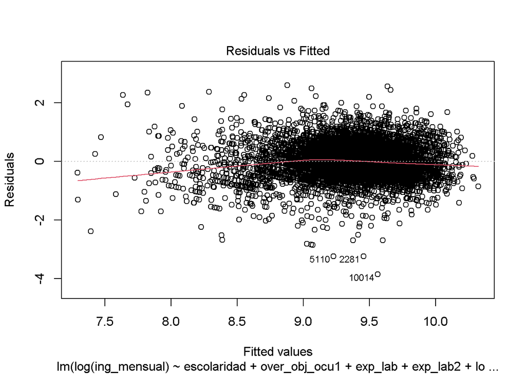

```r
# par(mfrow = c(2, 2))
plot(modelo_obj_jov_prof_amp, 1)
```

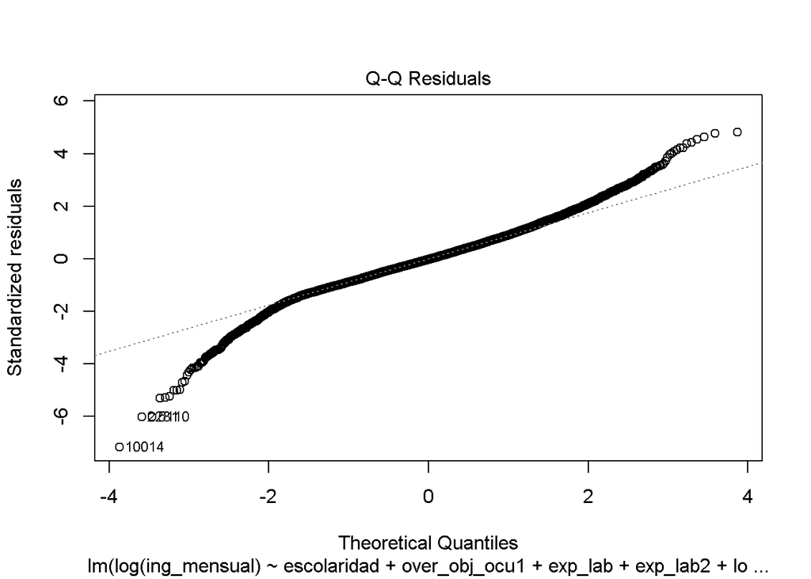

```r
# par(mfrow = c(2, 2))
plot(modelo_obj_jov_prof_amp, 2)
```

- Hay desviaciones en los extremos de la gráfica lo que parece indicar una distribución anormal de los residuos

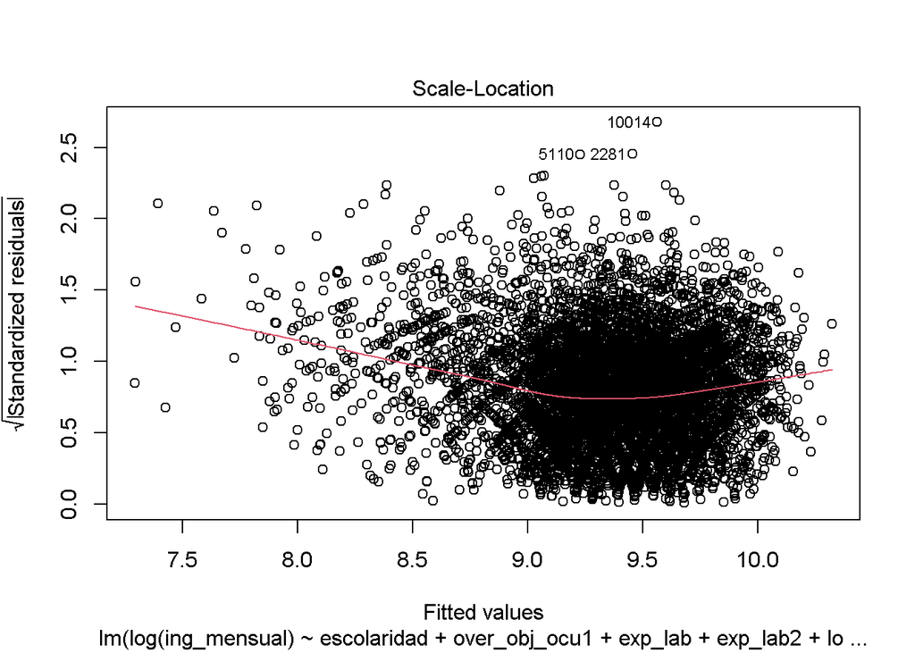

```r
# par(mfrow = c(2, 2))
plot(modelo_obj_jov_prof_amp, 3)
```

- La banda tiene forma de “U”, lo que parece indicar una varianza no constante de los residuos

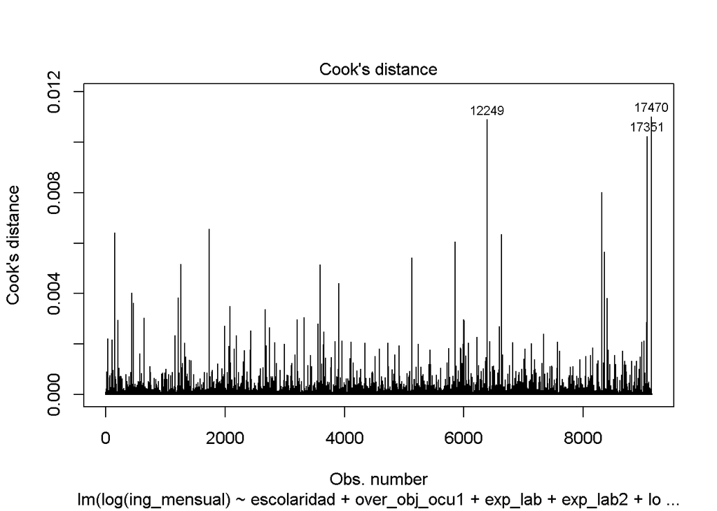

```r
# par(mfrow = c(2, 2))
plot(modelo_obj_jov_prof_amp, 4)
```

Histograma

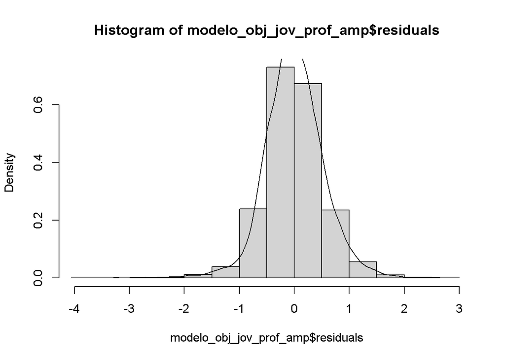

```r
hist(modelo_obj_jov_prof_amp$residuals, prob = TRUE)
lines(density(modelo_obj_jov_prof_amp$residuals))
```

- Parece que los residuos presentan una distribución normal con una media cercana al 0.

```r
moments::skewness(resid(modelo_obj_jov_prof_amp))
```

```
## [1] -0.1073446
```

- El coeficiente de asimetría indica que la distribución de los residuos está ligeramente sesgado a la izquierda

Pruebas estadísticas

```r
# normalidad
moments::jarque.test(resid(modelo_obj_jov_prof_amp))
```

```
##
##  Jarque-Bera Normality Test
##
## data:  resid(modelo_obj_jov_prof_amp)
## JB = 2062.6, p-value < 2.2e-16
## alternative hypothesis: greater
```

```r
nortest::ad.test(resid(modelo_obj_jov_prof_amp))
```

```
##
##  Anderson-Darling normality test
##
## data:  resid(modelo_obj_jov_prof_amp)
## A = 27.563, p-value < 2.2e-16
```

```r
# stats::shapiro.test(resid(modelo_obj_jov_prof_amp))

# homocedasticidad
lmtest::bptest(modelo_obj_jov_prof_amp)
```

```
##
##  studentized Breusch-Pagan test
##
## data:  modelo_obj_jov_prof_amp
## BP = 347.79, df = 15, p-value < 2.2e-16
```

```r
# autocorrelación
lmtest::dwtest(modelo_obj_jov_prof_amp)
```

```
##
##  Durbin-Watson test
##
## data:  modelo_obj_jov_prof_amp
## DW = 1.9904, p-value = 0.7603
## alternative hypothesis: true autocorrelation is greater than 0
```

- Se rechaza la hipótesis nula en las pruebas de normalidad (Anderson-Darling y Jarque-Bera), es decir, los residuos no se distribuyen normalmente
- Se rechaza la hipótesis nula en la prueba Breusch-Pagan, los residuos son heterocedásticos
- No se rechaza la hipótesis nula en la prueba Durbin-Watson, no hay presencia de autocorrelación de primer orden

Al momento de ejecutar la función `shapiro.test`, arroja un error por lo que se decide no utilizarla.

```
Error en stats::shapiro.test(resid(modelo_obj_jov_prof_amp)):
  sample size must be between 3 and 5000
```

# Referencias

ILO (2023). The International Standard Classification of Occupations (ISCO-08) companion guide. https://www.ilo.org/publications/international-standard-classification-occupations-isco-08-companion-guide

ILO (s.f.). Education and Mismatch Indicators (EMI database). ILOSTAT database description. https://ilostat.ilo.org/methods/concepts-and-definitions/description-education-and-mismatch-indicators

ILO (s.f.). International Standard Classification of Occupations (ISCO). ILOSTAT. https://ilostat.ilo.org/methods/concepts-and-definitions/classification-occupation

INEGI. (2011). Sistema Nacional de Clasificación de Ocupaciones 2011. SINCO. https://www.inegi.org.mx/app/biblioteca/ficha.html?upc=702825003336

INEGI. (2016). Clasificación mexicana de planes de estudio por campos de formación académica 2016. Educación superior y media superior. México: INEGI. https://www.inegi.org.mx/app/biblioteca/ficha.html?upc=702825003335

INEGI. (2020). Sistema Nacional de Clasificación de Ocupaciones 2019. SINCO. https://www.inegi.org.mx/app/biblioteca/ficha.html?upc=702825198411

INEGI. (2024). Encuesta Nacional de Ocupación y Empleo (ENOE). Estructura de la base de datos. https://www.inegi.org.mx/contenidos/programas/enoe/15ymas/doc/enoe_123_fd_c_bas_amp.pdf

OECD. (2019). Educación superior en México: Resultados y relevancia para el mercado laboral. París: OECD Publishing. https://doi.org/10.1787/a93ed2b7-es

UNESCO (2013). Clasificación Internacional Normalizada de la Educación CINE 2011. https://unesdoc.unesco.org/ark:/48223/pf0000220782

ILO. 2021. “Sólo la mitad de los trabajadores de todo el mundo ocupan puestos de trabajo correspondientes a su nivel de formación.” In *ILOSTAT*.

INEGI. 2016. *Clasificación mexicana de planes de estudio por campos de formación académica 2016. Educación superior y media superior.* México: INEGI.

INEGI. 2020. *Sistema Nacional de Clasificación de Ocupaciones 2019. SINCO*.

INEGI. 2024. *Encuesta Nacional de Ocupación y Empleo (ENOE). Estructura de la base de datos*.